# Classroom Attentiveness Monitor: Faculty Report

A Statistical Analysis and Reporting Dashboard in R (23AI502PC)

## 1. Executive Summary

This report provides a data-driven analysis of student engagement for the last recorded class session. The data was collected via an automated CV system (Module 1) and analyzed using R (Module 2).

- **Total Students Monitored:** 14
- **Overall Class Average Attentiveness:** 72.2%
- **Students with < 60% Avg. Attention:** 7

## 2. Class Attentiveness Over Time (Unit V)

This line graph shows the average attentiveness of the *entire class* from the beginning to the end of the session. This helps identify moments when engagement may have dropped (e.g., long lectures, difficult topics).

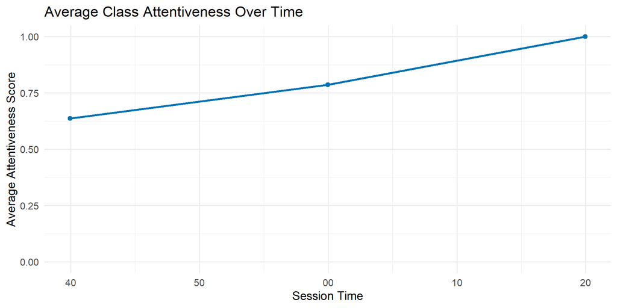

## 3. Individual Student Analysis (Unit II & V)

This section provides a detailed breakdown of each student’s performance.

[figure not shown]

### Detailed Student Data Table

This table provides the raw statistics for each student, including their average score, median, standard deviation (variance), and the number of data points collected for them.

Summary Statistics by Student (Unit II)

| roll_no | avg_score | median_score | std_dev | time_points |
| --- | --- | --- | --- | --- |
| student_4 | 0.30 | 0.3 | NA | 1 |
| student_5 | 0.30 | 0.3 | NA | 1 |
| student_6 | 0.30 | 0.3 | 0.00 | 3 |
| student_7 | 0.30 | 0.3 | 0.00 | 5 |
| student_8 | 0.30 | 0.3 | 0.00 | 4 |
| student_1 | 0.44 | 0.0 | 0.48 | 83 |
| student_2 | 0.57 | 0.5 | 0.16 | 106 |
| student_11 | 0.60 | 0.6 | 0.00 | 52 |
| student_9 | 0.66 | 0.5 | 0.25 | 40 |
| student_12 | 0.79 | 1.0 | 0.29 | 416 |
| student_0 | 0.88 | 1.0 | 0.21 | 110 |
| student_3 | 0.88 | 1.0 | 0.23 | 8 |
| student_10 | 1.00 | 1.0 | 0.00 | 2 |
| student_13 | 1.00 | 1.0 | 0.00 | 28 |